# Q Teleportation

Study Notes for [Q teleportation](https://quantum.country/teleportation)

Jay (notetaker)

last updated on: 2021-10-31

Quantum teleportation underlies many other phenomena in quantum computing and, more broadly, in quantum information science. For instance, it’s led to important ideas about reducing the effects of noise on quantum computers, and to new hardware ideas for building quantum computers. Because of applications such as these, teleportation is today viewed as a core primitive in quantum information science.

# 1 The teleportation protocol

Consider the case of teleporting the simplest possible quantum system – a qubit. Alice wants to teleport a qubit, $|\psi\rangle = \alpha|0\rangle + \beta|1\rangle$, to Bob.

We rule out

1. Alice physically sends the quibit to Bob.
2. Alice tells Bob the value of the amplitudes, $\alpha$ and $\beta$. In general, Alice may not know the values. In addition, there is no good way to measure the amplitudes.

Now let’s lay out the protocol.

*Step 1*. Create a Bell pair and give one to Alice and one to Bob.

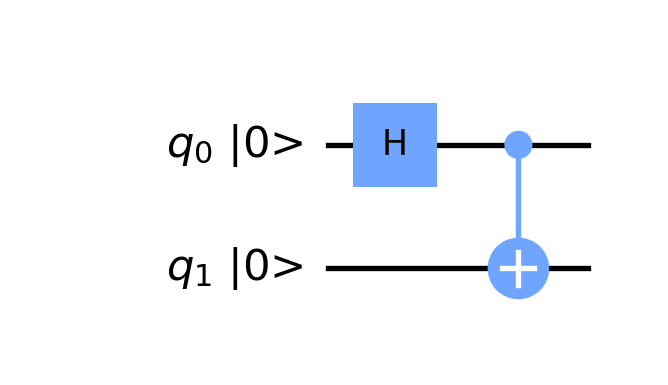

Construct an entangled Bell state.

Alice and Bob share a Bell state. That is, Alice and Bob each possesses a qubit of a two-qubit Bell state.

$$\frac{|00\rangle + |11\rangle}{\sqrt{2}}$$

This is an entangled Bell state that can be prepared using a Hadamard and CNOT gate.

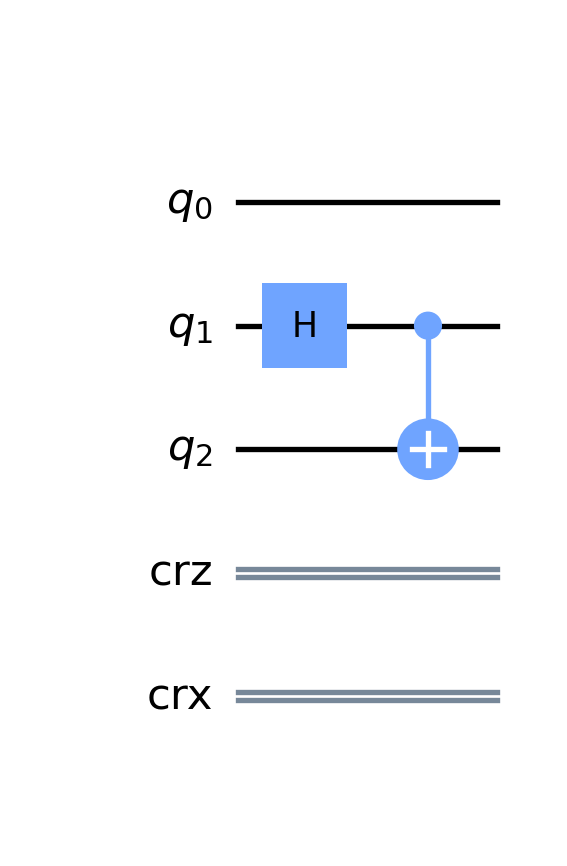

*Step 2.* Alice applies her gates.

Alice applies a CNOT gate to $q_1$, controlled by $|\psi\rangle$ (the qubit she is trying to send Bob). Then Alice applies a Hadamard gate to $|\psi\rangle$.

The circuit combining Step 1 and 2 is the following.

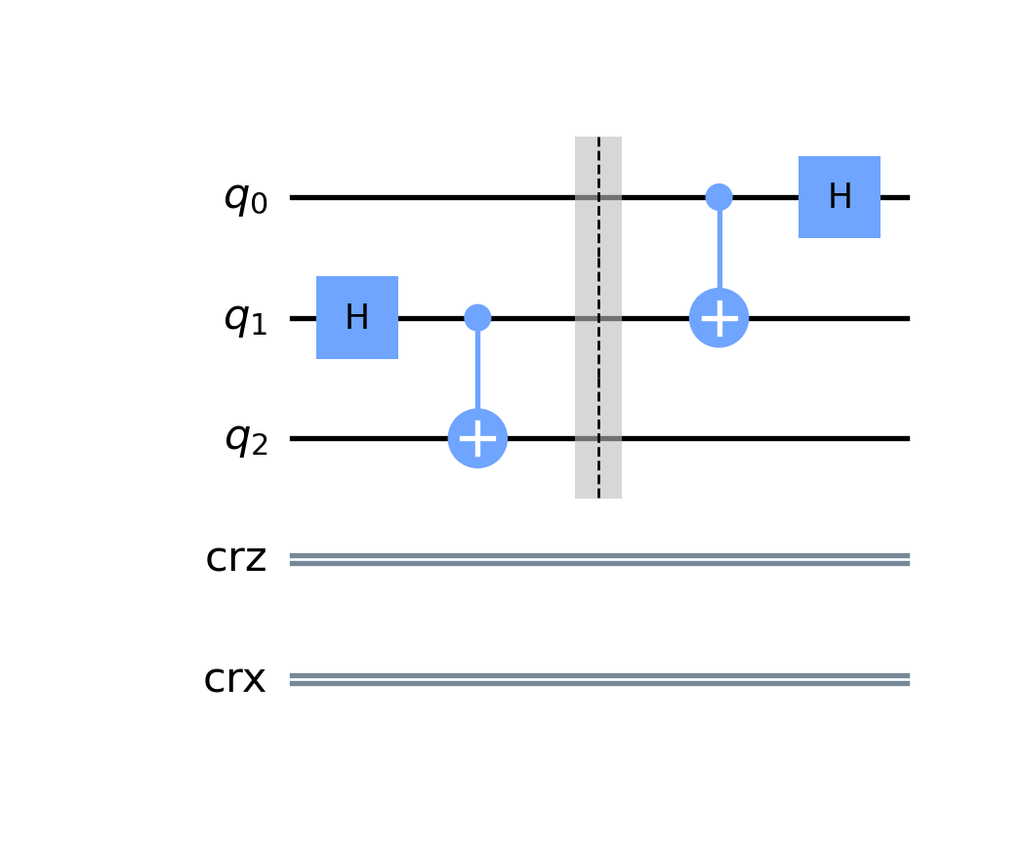

*Step 3*. Alice applies a measurement and send its result to Bob.

Next, Alice applies a measurement to both qubits that she owns, $|\psi\rangle$ and $q_1$, and stores this result in two classical bits. She then sends these two bits to Bob.

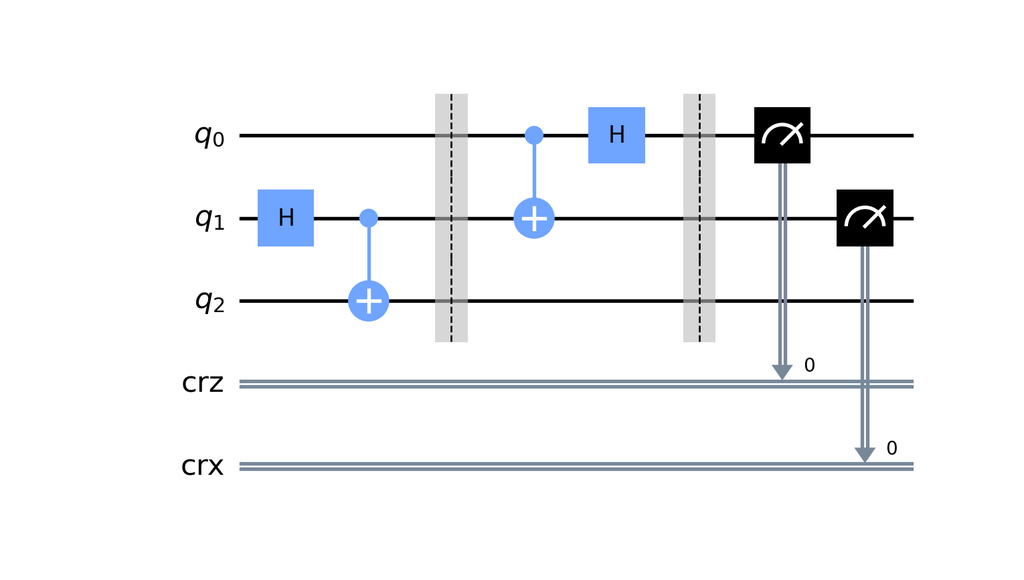

*Step 4*. Bob applies his gates accordingly and recovers $|\psi\rangle$.

Bob, who already has the qubit $q_2$, then applies the following gates to it depending on the state of the classical bits:

$$X |0\rangle = |1\rangle; \quad X |1\rangle = |0\rangle. \\
Z |0\rangle = |0\rangle; \quad Z |1\rangle = -|1\rangle.$$

$$\begin{align}
00 &\rightarrow \text{Do noting} \\
01 &\rightarrow \text{Apply X gate} \\
10 &\rightarrow \text{Apply Z gate} \\
11 &\rightarrow \text{Apply ZX gate}
\end{align}$$

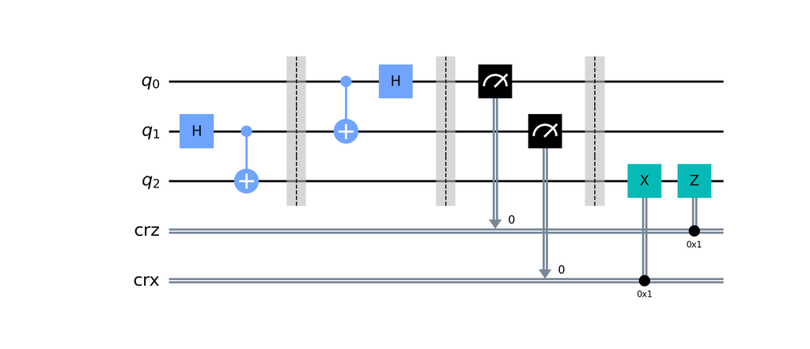

At the end of this protocol, Alice’s qubit has now teleported to Bob.

Note that

0. Alice never send Bob the qubit $|\psi\rangle$.
1. Alice only send Bob two classical bits.
2. Encoding the amplitudes $\alpha$ and $\beta$ would require, in principle, an infinite amount of classical information.
3. Quantum teleportation doesn’t enable faster-than-light communication.
4. At the end of the protocol, Alice no longer possesses $|\psi\rangle$ (hence teleportation).

# 2 How partial measurements work

Suppose we have a two-qubit system in the state

$$a|00\rangle + b|01\rangle + c|10\rangle + d|11\rangle.$$
Suppose we measure just the first qubit in the computational basis. We’d like to know

1. what the probabilities for the two measurement outcomes are; and
2. what the corresponding resulting state of the second qubit will be.

Regroup, we get

$$|0\rangle(a|0\rangle + b|1\rangle) + |1\rangle (c|0\rangle + d|1\rangle).$$
Measure $|0\rangle$ with probability $|a|^2 + |b|^2$. The resulting 2nd bit is $\frac{1}{\sqrt{|a|^2 + |b|^2}}(a|0\rangle + b|1\rangle)$.

# 3 Verifying the teleportation protocol works

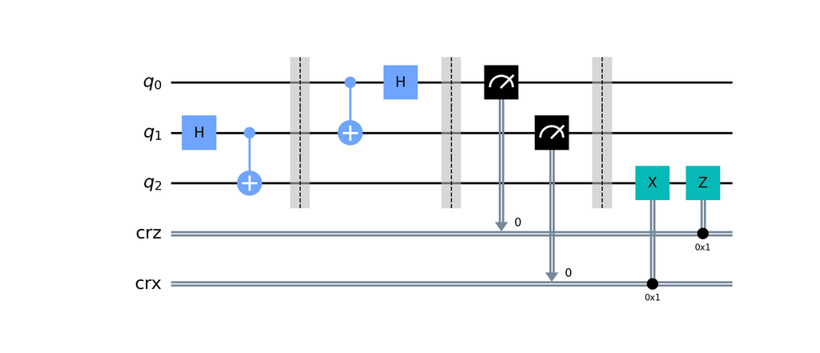

*Step 1*. Create a Bell pair and give one to Alice and one to Bob.

$$(\alpha|0\rangle + \beta|1\rangle)\frac{|00\rangle + |11\rangle}{\sqrt{2}}$$
*Step 2*. Alice applies her gates.

$$H |0\rangle = \frac{1}{\sqrt{2}}(|0\rangle+|1\rangle); \\ H |1\rangle = \frac{1}{\sqrt{2}}(|0\rangle-|1\rangle).$$

$$\begin{align}
&\quad\; (\alpha|0\rangle + \beta|1\rangle)\frac{|00\rangle + |11\rangle}{\sqrt{2}} \\
& = \frac{1}{\sqrt{2}}(\alpha|000\rangle+\alpha|011\rangle+\beta|100\rangle+\beta|111\rangle) \quad \text{(expand)} \\
&= \frac{1}{\sqrt{2}}(\alpha|000\rangle+\alpha|011\rangle+\beta|110\rangle+\beta|101\rangle) \quad \text{(apply CNOT gate)} \\
&= \frac{1}{2}(\alpha|000\rangle+\alpha|100\rangle+\alpha|011\rangle+\alpha|111\rangle + \beta|010\rangle-\beta|110\rangle\\
&\quad\quad\;\; +\beta|001\rangle-\beta|101\rangle) \quad \text{(apply H gate)}
\end{align}$$

*Step 3*. Alice applies a measurement in computational basis and send its result to Bob.

Rewrite the last equation in Step 2.

$$\frac{|00\rangle(\alpha|0\rangle + \beta|1\rangle) + |01\rangle(\alpha|1\rangle + \beta|0\rangle) + |10\rangle(\alpha|0\rangle - \beta|1\rangle) + |11\rangle(\alpha|1\rangle - \beta|0\rangle)}{2}$$
We can then list Alice’s result and corresponding state of Bob’s quibit.

| Outcome | Prob. | Bob’s State |
| --- | --- | --- |
| 00 | 1/4 | $\alpha\|0\rangle+\beta\|1\rangle=\|\psi\rangle$ |
| 01 | 1/4 | $\alpha\|1\rangle+\beta\|0\rangle=X\|\psi\rangle$ |
| 10 | 1/4 | $\alpha\|0\rangle-\beta\|1\rangle=Z\|\psi\rangle$ |
| 11 | 1/4 | $\alpha\|1\rangle-\beta\|0\rangle)=XZ\|\psi\rangle$ |

*Step 4*. Bob applies his gates accordingly and recovers $|\psi\rangle$.

Recall that $XX=I$ and $ZZ=I$.

Based on the two bits of classical information Alice send to Bob, Bob recovers $|\psi\rangle$.

## 3.1 Discussion

Teleportation isn’t really about transmitting objects over long distances. Rather, it’s about a counter-intuitive way of disassembling an unknown quantum state into classical information, using a fixed shared state and measurement, and then later recovering the original quantum state.